# Chap12 Section3

Mijeong Kim

```r
library(tsibble)
library(tsibbledata)
library(tibble)
library(dplyr)
library(knitr)
library(ggplot2)
library(fpp3)
library(fpp2)
library(seasonal)
library(feasts)
```

## 12.3 벡터 자기회귀 (Vector autoregressions; VAR)

기존의 시계열 예측 모델은 일반적으로 **단방향(unidirectional)** 관계만을 고려한다. 즉, 종속변수는 독립변수에 의해 영향을 받지만, 종속변수가 독립변수에 영향을 준다는 가능성은 무시된다.

그러나 실제 데이터에서는 변수들 간에 **상호작용**이 존재하는 경우가 많다. 이러한 경우에는 단방향 모델보다 **양방향(bi-directional)** 관계를 반영할 수 있는 모형이 적절하다.

#### 상호작용의 예시: 가처분 소득과 소비 지출

예를 들어, 다음과 같은 경제적 관계가 존재한다:

- 가처분 소득($I_t$)이 증가하면 소비 지출($C_t$)이 증가한다.
- 소비 지출이 증가하면 경제가 활성화되어 다시 가처분 소득도 증가한다.

이처럼 두 변수는 서로 영향을 주고받는 구조이다.

#### 실례: 2008–2009년 글로벌 금융위기

2008년 말, 호주 정부는 경기 부양을 위해 현금성 지원을 단행하였다. 이로 인해 크리스마스 소비가 급증하였고, 그 결과 소득이 증가하며 경기 회복의 선순환이 발생하였다.

#### VAR (Vector Autoregressive) 모형

이러한 **피드백 구조**를 다룰 수 있는 모델이 VAR이다.

#### 특징

- 모든 변수를 **내생 변수(endogenous variables)** 로 취급한다.
- 각 변수에 대해 **자신과 다른 변수들의 과거 값**을 회귀변수로 포함한다.
- 변수들이 **대칭적이고 동등하게** 다뤄진다.

#### 2변수 VAR(1) 모형

$$\begin{aligned}
y_{1,t} &= c_1 + \phi_{11,1} y_{1,t-1} + \phi_{12,1} y_{2,t-1} +
\varepsilon_{1,t} \\
y_{2,t} &= c_2 + \phi_{21,1} y_{1,t-1} + \phi_{22,1} y_{2,t-1} +
\varepsilon_{2,t}
\end{aligned}$$

같은 모형은 벡터형식으로도 쓸 수 있다.

$$y_t = c + \Phi_1 y_{t-1} + \varepsilon_t$$

여기서

$$y_t =
\begin{bmatrix}
y_{1,t} \\
y_{2,t}
\end{bmatrix},
\quad
c =
\begin{bmatrix}
c_1 \\
c_2
\end{bmatrix},
\quad
\Phi_1 =
\begin{bmatrix}
\phi_{11,1} & \phi_{12,1} \\
\phi_{21,1} & \phi_{22,1}
\end{bmatrix},
\quad
\varepsilon_t =
\begin{bmatrix}
\varepsilon_{1,t} \\
\varepsilon_{2,t}
\end{bmatrix}$$

이다. 일반적인 VAR($p$) 모형은

$$y_t = c + \Phi_1 y_{t-1} + \cdots + \Phi_p y_{t-p} + \varepsilon_t$$

처럼 쓸 수 있다.

여기서,

- $y_{1,t}$, $y_{2,t}$는 각각 시계열 변수의 t시점 값이다.
- $\phi_{ij,1}$는 $j$번째 변수의 1시차가 $i$번째 변수에 미치는 영향이다.
- $\varepsilon_{1,t}, \varepsilon_{2,t}$는 백색 잡음(white noise)이며, 서로 상관관계를 가질 수 있다.

#### VAR 모형 적합 방법

VAR 모형은 시계열 자료가 **정상성(stationarity)** 여부에 따라 다음과 같이 적합한다:

- **정상 시계열**: 자료에 직접 VAR을 적합 → **VAR in levels**
- **비정상 시계열**: 차분하여 정상화 후 VAR을 적합 → **VAR in differences**

모든 경우에서 추정은 **최소자승법(least squares)** 을 사용하며, 각 방정식을 독립적으로 추정한다. 목적은 각 방정식에서 잔차 제곱합을 최소화하는 것이다.

#### 공적분의 가능성과 VECM

시계열이 비정상이면서 **공적분(cointegration)** 관계가 존재하는 경우, 단순한 VAR이 아닌 **오차수정모형(VECM; Vector Error Correction Model)** 을 사용해야 한다.

공적분이란, 각 시계열 자체는 비정상이지만 어떤 **선형결합(linear combination)** 은 정상이라는 뜻이다. 예를 들어 두 시계열 $y_{1,t}$, $y_{2,t}$가 각각 1차 적분과정이면

$$y_{1,t} \sim I(1), \qquad y_{2,t} \sim I(1)$$

이다. 그런데 0이 아닌 어떤 벡터 $\beta = (\beta_1, \beta_2)'$가 존재하여

$$z_t = \beta'y_t = \beta_1 y_{1,t} + \beta_2 y_{2,t} \sim I(0)$$

가 되면, $y_{1,t}$와 $y_{2,t}$는 공적분되어 있다고 한다. 여기서 $I(0)$는 정상과정, $I(1)$는 한 번 차분하면 정상인 과정을 뜻한다.

즉, 각 시계열은 개별적으로는 랜덤워크처럼 움직일 수 있어도, 장기적으로는 어떤 균형 관계를 유지한다는 뜻이다. 가장 단순한 예는

$$y_{1,t} - y_{2,t} \sim I(0)$$

인 경우이다. 이때 두 변수의 차이는 평균 주변에서 움직이므로, 두 변수는 장기적으로 너무 멀리 벌어지지 않는다.

공적분이 존재하면 차분 VAR은 장기 균형 정보를 버리게 되고, levels VAR은 비정상성 때문에 허위회귀 문제가 생길 수 있다. 따라서 단기 변화와 장기 균형을 함께 반영하는 VECM을 사용한다.

허위회귀(spurious regression)는 실제로는 관련이 없는 비정상 시계열끼리 회귀했는데도 높은 $R^2$와 유의한 계수가 나타나는 현상이다. 이는 실제 관계가 아니라 공통 추세 때문에 생길 수 있으므로, 비정상 시계열을 수준 그대로 회귀한 결과는 그대로 해석하면 안 된다.

VECM의 기본 형태는 다음과 같다.

$$\Delta y_t
= c + \Pi y_{t-1}
+ \Gamma_1 \Delta y_{t-1}
+ \cdots
+ \Gamma_{p-1} \Delta y_{t-p+1}
+ \varepsilon_t$$

여기서 $\Pi$의 랭크가 $r > 0$이면

$$\Pi = \alpha \beta'$$

로 쓸 수 있다. 여기서 $\beta$는 공적분 벡터를 모아 놓은 행렬이고, $\alpha$는 각 변수의 조정 속도를 모아 놓은 행렬이다. 따라서 $\beta'y_{t-1}$는 장기 균형을 나타내는 공적분항이고, $\alpha\beta'y_{t-1}$는 그 불균형이 현재 변화에 어떻게 반영되는지를 보여준다. 즉, VECM은 단기 변화 $(\Delta y_t)$와 장기 불균형 $(\beta'y_{t-1})$을 함께 설명하는 모형이다. 정리하면, 공적분이 없으면 차분 VAR을 고려하고, 공적분이 있으면 VECM을 고려한다.

#### VAR 기반 예측 방법

VAR 모형은 **재귀적(recursive)** 방식으로 예측값을 생성한다.

예를 들어, 다음의 VAR(1) 모형이 적합되어 있다고 가정한다:

$$\begin{aligned}
\hat{y}_{1,T+1|T} &= \hat{c}_1 + \hat{\phi}_{11,1} y_{1,T} +
\hat{\phi}_{12,1} y_{2,T} \\
\hat{y}_{2,T+1|T} &= \hat{c}_2 + \hat{\phi}_{21,1} y_{1,T} +
\hat{\phi}_{22,1} y_{2,T}
\end{aligned}$$

이후의 예측도 같은 형식으로 계산하며, 예측값을 다음 단계의 입력으로 사용한다:

$$\hat{y}_{1,T+2|T} = \hat{c}_1 + \hat{\phi}_{11,1} \hat{y}_{1,T+1|T} +
\hat{\phi}_{12,1} \hat{y}_{2,T+1|T}$$

$$\hat{y}_{2,T+2|T} = \hat{c}_2 + \hat{\phi}_{21,1} \hat{y}_{1,T+1|T} +
\hat{\phi}_{22,1} \hat{y}_{2,T+1|T}$$

#### 변수 수와 시차 선택

VAR 모형을 구성할 때 두 가지 주요 결정을 해야 한다:

- **변수 개수 $K$**: 서로 상관된 변수만 포함하는 것이 일반적이다.
- **시차 수 $p$**: AIC, BIC 등의 정보 기준을 사용하여 선택한다. AICc는 과도한 시차를 선택하는 경향이 있으므로, BIC 사용이 권장된다.

VAR에서 추정해야 할 계수의 총 수는 다음과 같다:

$$\text{총 계수 수} = K + pK^2 \quad (\text{또는 방정식 당 } 1 + pK)$$

예를 들어, $K = 5$, $p = 3$인 경우 방정식 당 16개의 계수가 존재하며, 총 80개를 추정해야 한다.

#### 고차원 문제 해결 방법

고차원 문제를 완화하기 위한 방법으로는 다음이 있다:

- **희소 VAR(sparse VAR)**: 많은 계수를 0으로 설정
- **수축 추정(shrinkage estimation)**: 계수를 작게 조정하여 과적합 방지

#### VAR의 해석상 한계

VAR 모형은 **이론 기반이 없는(atheoretical)** 모델로 비판을 받는다. 모든 변수가 서로에게 영향을 준다고 가정하기 때문에 계수 해석이 직관적이지 않다.

#### VAR의 활용 예시

그럼에도 불구하고 VAR은 다음과 같은 상황에서 유용하다:

- 변수 간 해석 없이 다변량 예측을 수행할 때
- 한 변수가 다른 변수를 예측하는 데 유용한지를 검정할 때 (**Granger 인과성 검정**)
- **충격반응분석(Impulse response analysis)**: 특정 변수에 일시적 충격이 다른 변수에 미치는 영향 분석
- **예측오차 분산 분해(Forecast error variance decomposition)**: 특정 변수의 예측 오차에 기여한 다른 변수의 비중 분석

### Example: A VAR model for forecasting US consumption

```r
fit <- us_change |>
  model(
    aicc = VAR(vars(Consumption, Income)),
    bic = VAR(vars(Consumption, Income), ic = "bic")
  )
fit
```

```
## # A mable: 1 x 2
##               aicc              bic
##            <model>          <model>
## 1 <VAR(5) w/ mean> <VAR(1) w/ mean>
```

```r
glance(fit)
```

```
## # A tibble: 2 × 6
##   .model sigma2        log_lik   AIC  AICc   BIC
##   <chr>  <list>          <dbl> <dbl> <dbl> <dbl>
## 1 aicc   <dbl [2 × 2]>   -373.  798.  806.  883.
## 2 bic    <dbl [2 × 2]>   -408.  836.  837.  869.
```

AICc 기준으로는 VAR(5) 모형이, BIC 기준으로는 VAR(1) 모형이 선택되었다. 이는 일반적인 현상으로, BIC는 모수 수에 더 강한 패널티를 주기 때문에 더 단순한 모형을 선택하는 경향이 있다.

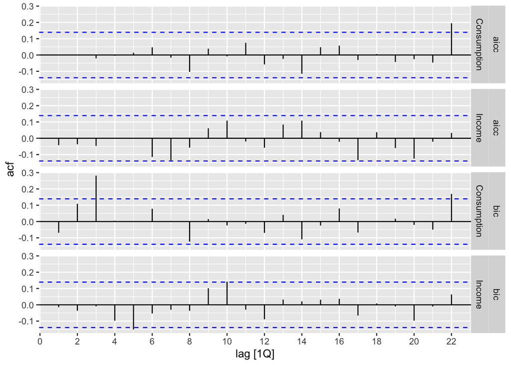

```r
fit |>
  augment() |>
  ACF(.innov) |>
  autoplot()
```

Figure 12.13: ACF of the residuals from the two VAR models. A VAR(5) model is selected by the AICc, while a VAR(1) model is selected using the BIC.

VAR(1) 모형의 잔차는 Consumption 변수에서 유의한 자기상관을 보이며, 정보를 충분히 반영하지 못하고 있다. 반면, VAR(5) 모형은 데이터의 정보를 효과적으로 포착하여 자기상관이 제거된 잔차를 보인다. Figure 12.14는 VAR(5) 모형을 이용한 예측 결과를 시각화한 것이다.

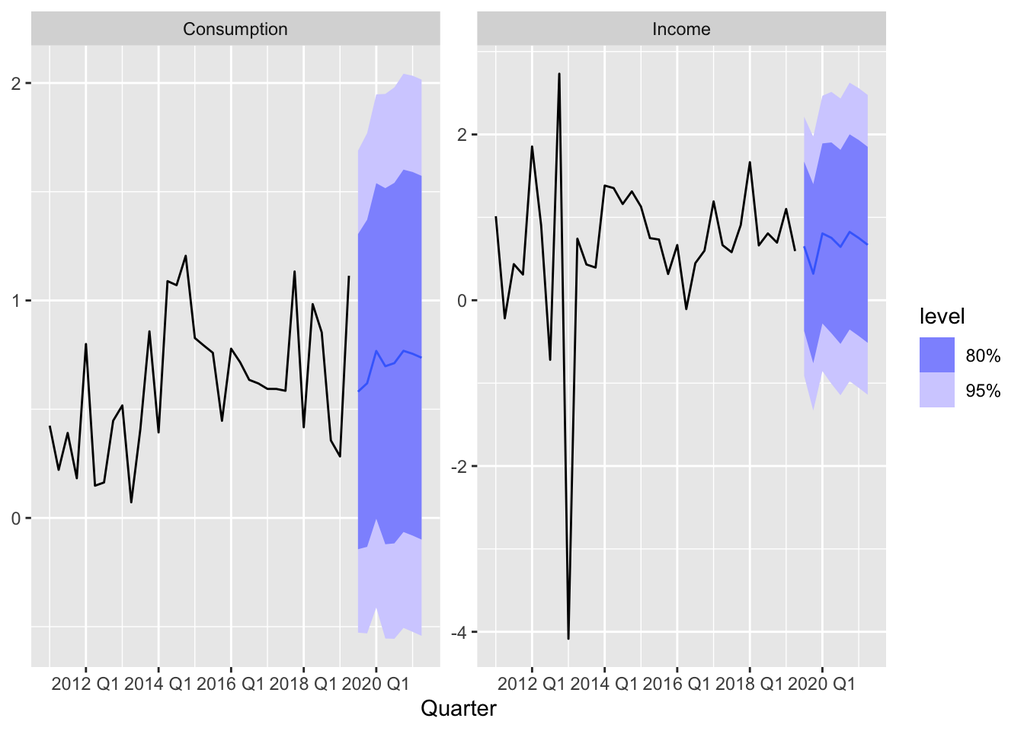

```r
fit |>
  select(aicc) |>
  forecast() |>
  autoplot(us_change |> filter(year(Quarter) > 2010))
```

Figure 12.14: Forecasts for US consumption and income generated from a VAR(5) model.